# Boston Crime Regression Analysis

Sudheesh Sreenilayam

2025-05-12

# 1 📌 Introduction

This project explores the relationship between per capita crime rate and various socio-economic predictors using the **Boston** housing dataset from the `MASS` package. Each predictor is evaluated using simple linear regression to identify significant relationships with crime rate (`crim`).

# 2 📦 Load Libraries and Data

```r
if (!require("MASS")) install.packages("MASS", repos = "https://cloud.r-project.org")
if (!require("ggplot2")) install.packages("ggplot2", repos = "https://cloud.r-project.org")
library(MASS)
library(ggplot2)
data("Boston")
```

# 3 🔍 Variable Overview

```r
str(Boston)
```

```
## 'data.frame':    506 obs. of  14 variables:
##  $ crim   : num  0.00632 0.02731 0.02729 0.03237 0.06905 ...
##  $ zn     : num  18 0 0 0 0 0 12.5 12.5 12.5 12.5 ...
##  $ indus  : num  2.31 7.07 7.07 2.18 2.18 2.18 7.87 7.87 7.87 7.87 ...
##  $ chas   : int  0 0 0 0 0 0 0 0 0 0 ...
##  $ nox    : num  0.538 0.469 0.469 0.458 0.458 0.458 0.524 0.524 0.524 0.524 ...
##  $ rm     : num  6.58 6.42 7.18 7 7.15 ...
##  $ age    : num  65.2 78.9 61.1 45.8 54.2 58.7 66.6 96.1 100 85.9 ...
##  $ dis    : num  4.09 4.97 4.97 6.06 6.06 ...
##  $ rad    : int  1 2 2 3 3 3 5 5 5 5 ...
##  $ tax    : num  296 242 242 222 222 222 311 311 311 311 ...
##  $ ptratio: num  15.3 17.8 17.8 18.7 18.7 18.7 15.2 15.2 15.2 15.2 ...
##  $ black  : num  397 397 393 395 397 ...
##  $ lstat  : num  4.98 9.14 4.03 2.94 5.33 ...
##  $ medv   : num  24 21.6 34.7 33.4 36.2 28.7 22.9 27.1 16.5 18.9 ...
```

**Note:** The response variable is `crim` (per capita crime rate by town). We will regress this onto each of the 13 predictors in the dataset.

# 4 📈 Simple Linear Regression for Each Predictor

We perform individual regressions of `crim` against each variable in the dataset and summarize the coefficients, p-values, and R-squared values.

```r
predictors <- setdiff(names(Boston), "crim")
results <- data.frame(Predictor = character(),
                      Coefficient = numeric(),
                      P_Value = numeric(),
                      R_Squared = numeric(),
                      stringsAsFactors = FALSE)

for (var in predictors) {
  model <- lm(Boston$crim ~ Boston[[var]])
  summary_model <- summary(model)
  results <- rbind(results, data.frame(
    Predictor = var,
    Coefficient = round(summary_model$coefficients[2, 1], 4),
    P_Value = signif(summary_model$coefficients[2, 4], 4),
    R_Squared = round(summary_model$r.squared, 4)
  ))
}

# Display sorted by R-squared (descending)
results_sorted <- results[order(-results$R_Squared), ]
knitr::kable(results_sorted, caption = "Simple Linear Regression Results: Crime vs. Each Predictor")
```

Simple Linear Regression Results: Crime vs. Each Predictor

|  | Predictor | Coefficient | P_Value | R_Squared |
| --- | --- | --- | --- | --- |
| 8 | rad | 0.6179 | 0.0000000 | 0.3913 |
| 9 | tax | 0.0297 | 0.0000000 | 0.3396 |
| 12 | lstat | 0.5488 | 0.0000000 | 0.2076 |
| 4 | nox | 31.2485 | 0.0000000 | 0.1772 |
| 2 | indus | 0.5098 | 0.0000000 | 0.1653 |
| 13 | medv | -0.3632 | 0.0000000 | 0.1508 |
| 11 | black | -0.0363 | 0.0000000 | 0.1483 |
| 7 | dis | -1.5509 | 0.0000000 | 0.1441 |
| 6 | age | 0.1078 | 0.0000000 | 0.1244 |
| 10 | ptratio | 1.1520 | 0.0000000 | 0.0841 |
| 5 | rm | -2.6841 | 0.0000006 | 0.0481 |
| 1 | zn | -0.0739 | 0.0000055 | 0.0402 |
| 3 | chas | -1.8928 | 0.2094000 | 0.0031 |

# 5 📊 Top Predictors Visualized

Below we visualize the relationship between crime and the **top 4 predictors** with the highest R² values using `ggplot2`.

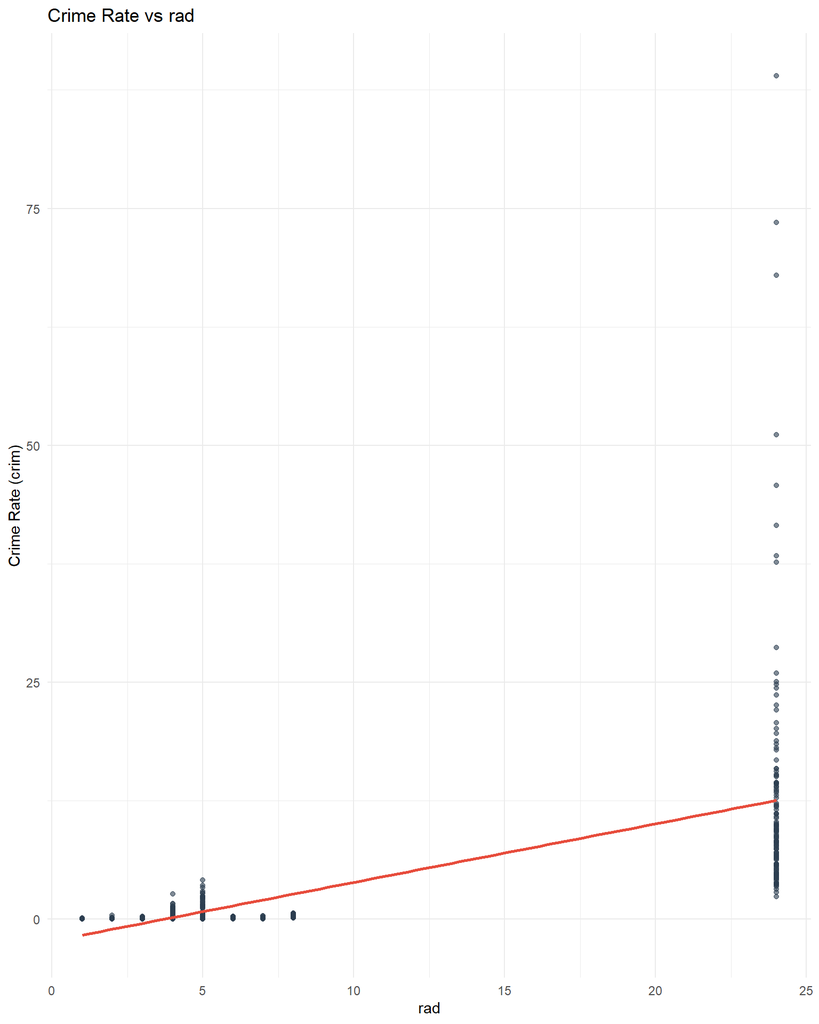

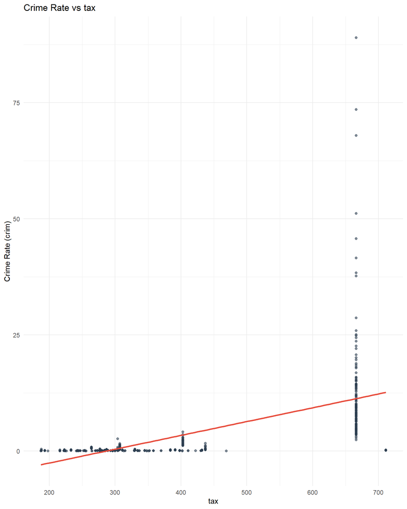

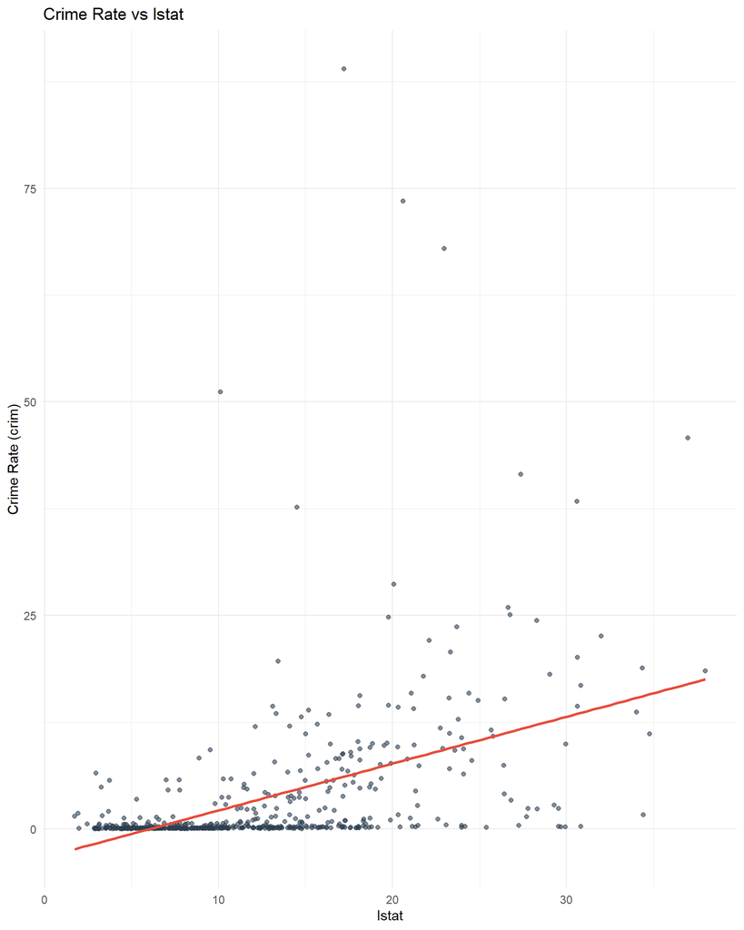

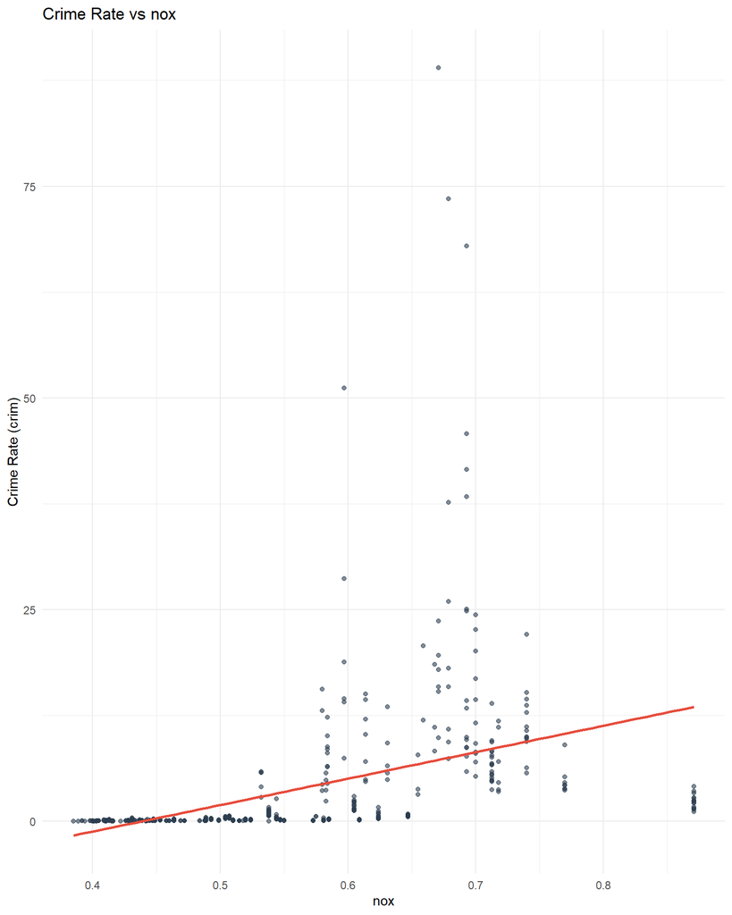

```r
top4 <- head(results_sorted$Predictor, 4)

plot_list <- lapply(top4, function(var) {
  ggplot(Boston, aes_string(x = var, y = "crim")) +
    geom_point(alpha = 0.6, color = "#2c3e50") +
    geom_smooth(method = "lm", se = FALSE, color = "#e74c3c") +
    labs(title = paste("Crime Rate vs", var),
         x = var,
         y = "Crime Rate (crim)") +
    theme_minimal()
})

# Print plots
for (plot in plot_list) {
  print(plot)
}
```

# 6 🧠 Interpretation

This suggests a subset of predictors can be useful for building a more complex multivariable regression model.